# cca

Jordan

2022-08-03

```r
# Load the required packages
library(dplyr)
library(vegan) # specpool () estimateR() poolaccum() estaccumR()
```

```r
library(ggplot2)
library(forcats )
library(reshape2)
library("readxl")
```

Importation des données.

```r
# Import
# Tour PC
setwd("D:/OneDrive - UMONS/UMONS/MA2/MEMOIRE/Statistique/R/STAT-MEMOIRE/RAW2")
# Laptop
#setwd("C:/Users/Jordan/OneDrive - UMONS/UMONS/MA2/MEMOIRE/Statistique/R/STAT-MEMOIRE/RAW2")

# Import
soil <- read_excel("Soil_R.xlsx")
granulo <- read_excel("granulo.xlsx")
granulo_simple <- read_excel("granulo.xlsx", sheet = "simple")
SpecCondStat <- read_excel("SpecCondStat.xls")
```

```r
# Nom plus compact
SCS <- SpecCondStat

# Retirer le site de Condorcet
SCS <- filter(SCS, TOPO != "Condorcet" )

# Renommer plus simplement
rename(SCS, "sp" = "SPEC.TAXPRIO" ) -> SCS
rename(SCS, "sites" = "TOPO" ) -> SCS

# Retirer les observations contenant l'espèce : "XXX"
# SCS <- filter(SCS, SPEC.TAXPRIO != "Bombus (Bombus)  sp." )

# Remplacement des noms d'espèces désuets
SCS$sp[SCS$sp == "Bombus lucorum"] <- "Terrestribombus  sp."
SCS$sp[SCS$sp == "Bombus terrestris"] <- "Terrestribombus  sp."
SCS$sp[SCS$sp == "Chalicodoma ericetorum"] <- "Megachile ericetorum"
SCS$sp[SCS$sp == "Halictus tumulorum"] <- "Seladonia tumulorum"

# Remplacement du noms de sites
SCS$sites[SCS$sites == "Les Gourmandes de la Procession"] <- "Gourmandes de la Procession"
soil$Site[soil$Site == "Les Gourmandes de la Procession"] <- "Gourmandes de la Procession"
granulo$Site[granulo$Site == "Les Gourmandes de la Procession"] <- "Gourmandes de la Procession"



#### Abbréger le nom des sites
# Liste des Potagers
Potagers <- c("Abbaye St-Denis", "Rue de l'Egalite", "Chasse Cambier", "Mel Legumes", "Gourmandes de la Procession", "Jean d'Avesnes", "Parc du bois de Mons", "Jardin Suspendu", "Ecole de l'Esperance", "Fond du petit marais")
# Liste des Parcs
Parcs <- c("Village des abeilles", "Siege social", "Parc du Beffroi", "Stievenart", "Parc Bonaert")

### Sol
## Metaux
# Créer une colonne Code en fonction des types de sites
soil$Code <- fct_collapse(
    soil$Site,
    "Potager" = Potagers,
    "Parc" = Parcs)

# Garder pour rownames
soil_site_name <- select(soil, Site)


## Granulo
# Créer une colonne Code en fonction des types de sites
granulo$Code <- fct_collapse(
    granulo$Site,
    "Potager" = Potagers,
    "Parc" = Parcs)

# substring prend les premiers caractères, abbreviate abrège comme il le sent
granulo$code_site <- abbreviate(granulo$Site)
# retirer les apostrophes
granulo$code_site <- gsub("'", "", granulo$code_site)
```

```r
# Granulométrie
#Granulo_site_name <- select(granulo, code_site)
Granulo <- granulo[,2:6]
#row.names(Granulo) <- Granulo_site_name
```

```r
# Preparation des données
data_bee_sp <- select(SCS, sp, N, sites)
data_bee_sp <- as.data.frame(data_bee_sp)
data_bee_sp <- aggregate(N ~ sp + sites, data = data_bee_sp, sum)
data_bee_sp <- xtabs(N ~ sites + sp, data_bee_sp)
data_bee_sp <- type.convert(data_bee_sp)
```

# 1 CCA sur toutes les variables granulo, non centrées et non réduites

```r
spe <- data_bee_sp
# le "." signifie contre toutes les var env; 1 : signifie aucune var env
spe.cca <- cca(spe ~ ., Granulo)
summary(spe.cca) # Scaling 2 (default)
```

```
##
## Call:
## cca(formula = spe ~ Argile + `Limon fin` + `Limon grossier` +      `Sable fin` + `Sable grossier`, data = Granulo)
##
## Partitioning of scaled Chi-square:
##               Inertia Proportion
## Total          2.0139     1.0000
## Constrained    0.6255     0.3106
## Unconstrained  1.3884     0.6894
##
## Eigenvalues, and their contribution to the scaled Chi-square
##
## Importance of components:
##                          CCA1    CCA2    CCA3    CCA4    CCA5    CA1    CA2
## Eigenvalue            0.16046 0.14904 0.13215 0.10097 0.08286 0.3182 0.2661
## Proportion Explained  0.07968 0.07401 0.06562 0.05014 0.04114 0.1580 0.1322
## Cumulative Proportion 0.07968 0.15368 0.21930 0.26944 0.31058 0.4686 0.6007
##                          CA3    CA4     CA5     CA6     CA7     CA8     CA9
## Eigenvalue            0.2278 0.1543 0.12125 0.09971 0.07557 0.06953 0.05596
## Proportion Explained  0.1131 0.0766 0.06021 0.04951 0.03752 0.03453 0.02779
## Cumulative Proportion 0.7138 0.7904 0.85065 0.90016 0.93769 0.97221 1.00000
##
## Accumulated constrained eigenvalues
## Importance of components:
##                         CCA1   CCA2   CCA3   CCA4    CCA5
## Eigenvalue            0.1605 0.1490 0.1322 0.1010 0.08286
## Proportion Explained  0.2565 0.2383 0.2113 0.1614 0.13247
## Cumulative Proportion 0.2565 0.4948 0.7061 0.8675 1.00000
##
## Scaling 2 for species and site scores
## * Species are scaled proportional to eigenvalues
## * Sites are unscaled: weighted dispersion equal on all dimensions
##
##
## Species scores
##
##                               CCA1      CCA2      CCA3       CCA4      CCA5
## Andrena bicolor           -0.98439 -0.055693 -0.326486 -0.8849289  0.030967
## Andrena carantonica        0.18928 -0.359545 -0.298710  0.0263910  0.559635
## Andrena chrysosceles      -1.28180  0.482977  1.152981 -0.9740700  0.105496
```

[output cut: 215 more lines]

```
## Parc du bois de Mons         1.0152 -0.77704  0.1302  0.80154  0.4752 -0.214188
## Rue de l'Egalite             0.1954  0.65911  2.7550 -0.37251 -0.9143 -1.399800
## Siege social                -1.2818  0.48298  1.1530 -0.97407  0.1055  3.119552
## Stievenart                   1.6194  0.61832 -0.8782 -0.88198 -1.7420  0.176825
## Village des abeilles        -0.8094 -0.71102  0.1158  0.28071 -0.5503  0.129544
##
##
## Biplot scores for constraining variables
##
##                     CCA1    CCA2     CCA3    CCA4     CCA5 CA1
## Argile            0.3468  0.4212  0.49476 -0.5349 -0.41401   0
## `Limon fin`       0.6791  0.4781  0.14331 -0.5362 -0.04599   0
## `Limon grossier`  0.6093  0.6576 -0.02243 -0.3847 -0.21851   0
## `Sable fin`      -0.8111 -0.4266 -0.25617  0.2573  0.16843   0
## `Sable grossier` -0.1030 -0.6241  0.05008  0.7430  0.21262   0
```

```r
# Unadjusted and adjusted R^2 - like statistics
RsquareAdj(spe.cca)
```

```
## $r.squared
## [1] 0.3105845
##
## $adj.r.squared
## [1] -0.06879352
```

## 1.1

VIF 36999 pour le sable fin, le plus faible est l’argile avec 3929

```r
vif.cca(spe.cca)
```

```
##           Argile      `Limon fin` `Limon grossier`      `Sable fin`
##         3929.518        11634.658        14379.172        36999.555
## `Sable grossier`
##        14105.979
```

# 2 Test avec 4 variables

La proportion d’inertie contrainte diminue (comme prévu). On a un vif max de 10

```r
spe <- data_bee_sp
# le "." signifie contre toutes les var env; 1 : signifie aucune var env
spe.cca <- cca(spe ~ ., Granulo[c("Argile", "Limon fin", "Limon grossier", "Sable grossier")])
summary(spe.cca) # Scaling 2 (default)
```

```
##
## Call:
## cca(formula = spe ~ Argile + `Limon fin` + `Limon grossier` +      `Sable grossier`, data = Granulo[c("Argile", "Limon fin",      "Limon grossier", "Sable grossier")])
##
## Partitioning of scaled Chi-square:
##               Inertia Proportion
## Total           2.014     1.0000
## Constrained     0.503     0.2498
## Unconstrained   1.511     0.7502
##
## Eigenvalues, and their contribution to the scaled Chi-square
##
## Importance of components:
##                         CCA1   CCA2    CCA3    CCA4    CA1    CA2    CA3
## Eigenvalue            0.1591 0.1386 0.11049 0.09488 0.3192 0.2741 0.2292
## Proportion Explained  0.0790 0.0688 0.05486 0.04711 0.1585 0.1361 0.1138
## Cumulative Proportion 0.0790 0.1478 0.20267 0.24978 0.4083 0.5444 0.6582
##                           CA4     CA5     CA6     CA7     CA8     CA9    CA10
## Eigenvalue            0.16120 0.13227 0.10046 0.09846 0.07275 0.06802 0.05520
## Proportion Explained  0.08004 0.06568 0.04988 0.04889 0.03613 0.03378 0.02741
## Cumulative Proportion 0.73823 0.80391 0.85379 0.90268 0.93881 0.97259 1.00000
##
## Accumulated constrained eigenvalues
## Importance of components:
##                         CCA1   CCA2   CCA3    CCA4
## Eigenvalue            0.1591 0.1386 0.1105 0.09488
## Proportion Explained  0.3163 0.2754 0.2196 0.18862
## Cumulative Proportion 0.3163 0.5917 0.8114 1.00000
##
## Scaling 2 for species and site scores
## * Species are scaled proportional to eigenvalues
## * Sites are unscaled: weighted dispersion equal on all dimensions
##
##
## Species scores
##
##                                 CCA1      CCA2      CCA3     CCA4       CA1
## Andrena bicolor           -0.9982643  0.406555 -0.522608  0.63545  0.466058
## Andrena carantonica        0.0687388 -0.090676  0.557664  0.48835  1.018601
## Andrena chrysosceles      -0.9981978 -0.328168 -1.447754  0.38439  2.965196
```

[output cut: 246 more lines]

```
## Parc du Beffroi              1.26900
## Parc du bois de Mons        -0.09653
## Rue de l'Egalite             0.26428
## Siege social                 1.66316
## Stievenart                  -1.01543
## Village des abeilles        -1.41583
##
##
## Biplot scores for constraining variables
##
##                     CCA1     CCA2    CCA3     CCA4 CA1 CA2
## Argile            0.4677 -0.06093 -0.8801 -0.05376   0   0
## `Limon fin`       0.7852  0.15609 -0.5346  0.27082   0   0
## `Limon grossier`  0.7566  0.40962 -0.5078  0.04396   0   0
## `Sable grossier` -0.2551 -0.50333  0.7788 -0.27408   0   0
```

```r
# Unadjusted and adjusted R^2 - like statistics
RsquareAdj(spe.cca)
```

```
## $r.squared
## [1] 0.2497786
##
## $adj.r.squared
## [1] -0.04778146
```

## 2.1 Vif max de 10 pour limon fin et grossier

```r
vif.cca(spe.cca)
```

```
##           Argile      `Limon fin` `Limon grossier` `Sable grossier`
##         3.442280        10.587433        10.424260         3.333497
```

# 3 Test avec 3 variables seulement.

On perd toujours en proportion contrainte avec un R² faible…

```r
spe <- data_bee_sp
# le "." signifie contre toutes les var env; 1 : signifie aucune var env
spe.cca <- cca(spe ~ ., Granulo[c("Argile", "Limon grossier", "Sable grossier")])
summary(spe.cca) # Scaling 2 (default)
```

```
##
## Call:
## cca(formula = spe ~ Argile + `Limon grossier` + `Sable grossier`,      data = Granulo[c("Argile", "Limon grossier", "Sable grossier")])
##
## Partitioning of scaled Chi-square:
##               Inertia Proportion
## Total          2.0139     1.0000
## Constrained    0.3959     0.1966
## Unconstrained  1.6180     0.8034
##
## Eigenvalues, and their contribution to the scaled Chi-square
##
## Importance of components:
##                          CCA1   CCA2    CCA3    CA1    CA2    CA3     CA4
## Eigenvalue            0.15622 0.1295 0.11018 0.3210 0.2753 0.2328 0.16218
## Proportion Explained  0.07757 0.0643 0.05471 0.1594 0.1367 0.1156 0.08053
## Cumulative Proportion 0.07757 0.1419 0.19658 0.3560 0.4927 0.6083 0.68882
##                           CA5    CA6     CA7     CA8     CA9    CA10    CA11
## Eigenvalue            0.15509 0.1102 0.09850 0.07473 0.07144 0.06586 0.05091
## Proportion Explained  0.07701 0.0547 0.04891 0.03711 0.03547 0.03270 0.02528
## Cumulative Proportion 0.76583 0.8205 0.86943 0.90654 0.94202 0.97472 1.00000
##
## Accumulated constrained eigenvalues
## Importance of components:
##                         CCA1   CCA2   CCA3
## Eigenvalue            0.1562 0.1295 0.1102
## Proportion Explained  0.3946 0.3271 0.2783
## Cumulative Proportion 0.3946 0.7217 1.0000
##
## Scaling 2 for species and site scores
## * Species are scaled proportional to eigenvalues
## * Sites are unscaled: weighted dispersion equal on all dimensions
##
##
## Species scores
##
##                                CCA1     CCA2       CCA3       CA1      CA2
## Andrena bicolor            0.928957  0.74658  6.439e-01  0.505257  0.87850
## Andrena carantonica        0.046658  0.19607 -4.805e-01  1.076298 -1.41432
## Andrena chrysosceles       1.056684 -0.10678  1.489e+00  2.990348  1.53250
```

[output cut: 213 more lines]

```
## Parc Bonaert                -1.42613  1.4260 -0.1586  0.05121  0.17442 -0.55508
## Parc du Beffroi             -1.17786 -0.6764 -0.4765  0.92239  1.30903 -0.13310
## Parc du bois de Mons        -0.50517 -0.7581 -1.1247 -0.14769 -0.02151  0.11100
## Rue de l'Egalite            -0.33753 -2.1022  1.8888 -1.45111  0.35130  0.95860
## Siege social                 1.05668 -0.1068  1.4890  2.99035  1.53250 -0.52385
## Stievenart                  -1.87508  0.3928  0.9540  0.25642 -1.06970 -0.48446
## Village des abeilles         0.96448 -0.4195 -0.1223  0.12736 -1.51484 -1.28887
##
##
## Biplot scores for constraining variables
##
##                     CCA1    CCA2    CCA3 CA1 CA2 CA3
## Argile           -0.4617 -0.2483  0.8516   0   0   0
## `Limon grossier` -0.8344  0.1991  0.5140   0   0   0
## `Sable grossier`  0.3527 -0.4365 -0.8277   0   0   0
```

```r
# Unadjusted and adjusted R^2 - like statistics
RsquareAdj(spe.cca)
```

```
## $r.squared
## [1] 0.1965836
##
## $adj.r.squared
## [1] -0.02054995
```

# 4 CCA sur toutes les variables granulo, centrées et réduites

cela ne change pas grand chose de centrer et réduire.

```r
# centrer et réduire
Granulo_scale <- scale(Granulo, center = TRUE, scale = TRUE)
str(Granulo_scale)
```

```
##  num [1:15, 1:5] -0.1253 0.1464 -1.3931 -0.0347 -1.2346 ...
##  - attr(*, "dimnames")=List of 2
##   ..$ : NULL
##   ..$ : chr [1:5] "Argile" "Limon fin" "Limon grossier" "Sable fin" ...
##  - attr(*, "scaled:center")= Named num [1:5] 10.8 11.8 15.1 40.5 21.8
##   ..- attr(*, "names")= chr [1:5] "Argile" "Limon fin" "Limon grossier" "Sable fin" ...
##  - attr(*, "scaled:scale")= Named num [1:5] 4.42 7.66 8.45 13.38 8.35
##   ..- attr(*, "names")= chr [1:5] "Argile" "Limon fin" "Limon grossier" "Sable fin" ...
```

```r
summary(Granulo_scale)
```

```
##      Argile           Limon fin       Limon grossier      Sable fin
##  Min.   :-1.39305   Min.   :-1.1024   Min.   :-1.2012   Min.   :-1.7788
##  1st Qu.:-0.58937   1st Qu.:-0.8411   1st Qu.:-0.7691   1st Qu.:-0.7810
##  Median :-0.03471   Median :-0.2403   Median :-0.3725   Median : 0.3587
##  Mean   : 0.00000   Mean   : 0.0000   Mean   : 0.0000   Mean   : 0.0000
##  3rd Qu.: 0.46335   3rd Qu.: 0.5956   3rd Qu.: 0.6219   3rd Qu.: 0.7437
##  Max.   : 2.18391   Max.   : 2.1107   Max.   : 1.9360   Max.   : 1.3528
##  Sable grossier
##  Min.   :-1.5515
##  1st Qu.:-0.6536
##  Median : 0.1484
##  Mean   : 0.0000
##  3rd Qu.: 0.5974
##  Max.   : 2.0399
```

CCA granulo c/r Cela ne change rien au résultat

```r
spe <- data_bee_sp
spe.cca <- cca(spe ~ ., as.data.frame(Granulo_scale))
summary(spe.cca) # Scaling 2 (default)
```

```
##
## Call:
## cca(formula = spe ~ Argile + `Limon fin` + `Limon grossier` +      `Sable fin` + `Sable grossier`, data = as.data.frame(Granulo_scale))
##
## Partitioning of scaled Chi-square:
##               Inertia Proportion
## Total          2.0139     1.0000
## Constrained    0.6255     0.3106
## Unconstrained  1.3884     0.6894
##
## Eigenvalues, and their contribution to the scaled Chi-square
##
## Importance of components:
##                          CCA1    CCA2    CCA3    CCA4    CCA5    CA1    CA2
## Eigenvalue            0.16046 0.14904 0.13215 0.10097 0.08286 0.3182 0.2661
## Proportion Explained  0.07968 0.07401 0.06562 0.05014 0.04114 0.1580 0.1322
## Cumulative Proportion 0.07968 0.15368 0.21930 0.26944 0.31058 0.4686 0.6007
##                          CA3    CA4     CA5     CA6     CA7     CA8     CA9
## Eigenvalue            0.2278 0.1543 0.12125 0.09971 0.07557 0.06953 0.05596
## Proportion Explained  0.1131 0.0766 0.06021 0.04951 0.03752 0.03453 0.02779
## Cumulative Proportion 0.7138 0.7904 0.85065 0.90016 0.93769 0.97221 1.00000
##
## Accumulated constrained eigenvalues
## Importance of components:
##                         CCA1   CCA2   CCA3   CCA4    CCA5
## Eigenvalue            0.1605 0.1490 0.1322 0.1010 0.08286
## Proportion Explained  0.2565 0.2383 0.2113 0.1614 0.13247
## Cumulative Proportion 0.2565 0.4948 0.7061 0.8675 1.00000
##
## Scaling 2 for species and site scores
## * Species are scaled proportional to eigenvalues
## * Sites are unscaled: weighted dispersion equal on all dimensions
##
##
## Species scores
##
##                               CCA1      CCA2      CCA3       CCA4      CCA5
## Andrena bicolor           -0.98439 -0.055693 -0.326486 -0.8849289  0.030967
## Andrena carantonica        0.18928 -0.359545 -0.298710  0.0263910  0.559635
## Andrena chrysosceles      -1.28180  0.482977  1.152981 -0.9740700  0.105496
```

[output cut: 215 more lines]

```
## Parc du bois de Mons         1.0152 -0.77704  0.1302  0.80154  0.4752 -0.214188
## Rue de l'Egalite             0.1954  0.65911  2.7550 -0.37251 -0.9143 -1.399800
## Siege social                -1.2818  0.48298  1.1530 -0.97407  0.1055  3.119552
## Stievenart                   1.6194  0.61832 -0.8782 -0.88198 -1.7420  0.176825
## Village des abeilles        -0.8094 -0.71102  0.1158  0.28071 -0.5503  0.129544
##
##
## Biplot scores for constraining variables
##
##                     CCA1    CCA2     CCA3    CCA4     CCA5 CA1
## Argile            0.3468  0.4212  0.49476 -0.5349 -0.41401   0
## `Limon fin`       0.6791  0.4781  0.14331 -0.5362 -0.04599   0
## `Limon grossier`  0.6093  0.6576 -0.02243 -0.3847 -0.21851   0
## `Sable fin`      -0.8111 -0.4266 -0.25617  0.2573  0.16843   0
## `Sable grossier` -0.1030 -0.6241  0.05008  0.7430  0.21262   0
```

```r
# Unadjusted and adjusted R^2 - like statistics
RsquareAdj(spe.cca)
```

```
## $r.squared
## [1] 0.3105845
##
## $adj.r.squared
## [1] -0.06976256
```

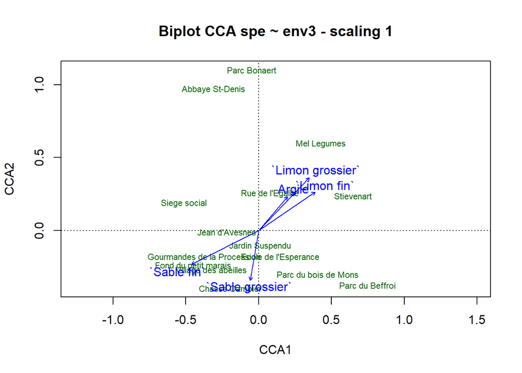

```r
# CCA scaling 1 biplot without species (using lc site scores)
plot(spe.cca,
scaling = 1,
display = c("lc", "cn"),
main = "Biplot CCA spe ~ env3 - scaling 1"
)
```

# 5 CCA sur les espèces terricoles

##5.1 importation et nettoyage des données Contrainte 0.3532 R² 0.35

```r
terricole <- filter(traits, Nest_area == "Soil")

# Preparation des données
terricole <- select(terricole, sp, N, site)
terricole <- as.data.frame(terricole)
terricole <- aggregate(N ~ sp + site, data = terricole, sum)
terricole <- xtabs(N ~ site + sp, terricole)
terricole <- type.convert(terricole)
```